# Shark_Tank_US_Prediction_Code

First we load the dataset zip file and unzip it.

```python
!unzip /content/shark_tank_data.zip
```

Then we use pandas library to get read the csv file

```python
import pandas as pd

df = pd.read_csv('Shark Tank US dataset.csv')
```

```python
df.head()
```

```python
num_rows = len(df)
print("Number of rows:", num_rows)
```

```
Number of rows: 1365
```

```python
df.columns
```

Below we can see all the column names of the dataset

```
Index(['Season Number', 'Startup Name', 'Episode Number', 'Pitch Number',
       'Season Start', 'Season End', 'Original Air Date', 'Industry',
       'Business Description', 'Company Website', 'Pitchers Gender',
       'Pitchers Average Age', 'Pitchers City', 'Pitchers State',
       'Entrepreneur Names', 'Multiple Entrepreneurs', 'US Viewership',
       'Original Ask Amount', 'Original Offered Equity', 'Valuation Requested',
       'Got Deal', 'Total Deal Amount', 'Total Deal Equity', 'Deal Valuation',
       'Number of Sharks in Deal', 'Investment Amount Per Shark',
       'Equity Per Shark', 'Royalty Deal', 'Advisory Shares Equity', 'Loan',
       'Deal Has Conditions', 'Barbara Corcoran Investment Amount',
       'Barbara Corcoran Investment Equity', 'Mark Cuban Investment Amount',
       'Mark Cuban Investment Equity', 'Lori Greiner Investment Amount',
       'Lori Greiner Investment Equity', 'Robert Herjavec Investment Amount',
       'Robert Herjavec Investment Equity', 'Daymond John Investment Amount',
       'Daymond John Investment Equity', 'Kevin O Leary Investment Amount',
       'Kevin O Leary Investment Equity', 'Guest Investment Amount',
       'Guest Investment Equity', 'Guest Name', 'Barbara Corcoran Present',
       'Mark Cuban Present', 'Lori Greiner Present', 'Robert Herjavec Present',
       'Daymond John Present', 'Kevin O Leary Present', 'Guest Present'],
      dtype='object')
```

# General Information about the Show

Season Number: Identifies the season of Shark Tank; useful for tracking trends across seasons.

Startup Name: Name of the startup; not directly useful for prediction but can help with descriptive analysis.

Episode Number: Episode where the pitch aired; helpful to see if episode positioning affects deals.

Pitch Number: Order of the pitch in the episode; can be useful for determining any patterns related to pitch order.

Season Start / Season End: Start and end dates of the season; useful for understanding time-based trends.

Original Air Date: The date the pitch aired; might affect viewership or investment based on seasonal factors.

# Business and Pitch Information

Industry: The industry of the startup (e.g., tech, food, etc.); a key feature for predicting investment preferences.

Business Description: Description of the business; qualitative data that could be processed using NLP for insights.

Company Website: URL of the startup’s website; not directly useful for prediction unless analyzed for metadata.

# Entrepreneur Information

Pitchers Gender: Gender(s) of the entrepreneurs; important for studying gender biases.

Pitchers Average Age: Average age of the pitching team; might correlate with investment likelihood.

Pitchers City: City where the entrepreneurs are based; location-based trends might exist.

Pitchers State: State where the entrepreneurs are based; could help analyze geographic preferences.

Entrepreneur Names: Names of the entrepreneurs; likely not useful for prediction but helpful for identification.

Multiple Entrepreneurs: Indicates whether multiple entrepreneurs are pitching; team dynamics might influence investments.

# Show Metrics

US Viewership: Number of viewers for the episode; higher viewership might lead to higher deal likelihood or value.

# Investment and Financial Details

Original Ask Amount: The amount of money the entrepreneurs initially requested; a critical predictor.

Original Offered Equity: Percentage of equity offered by the entrepreneurs; important for deal valuation.

Valuation Requested: Implied valuation based on the ask and equity offered; key financial metric.

Got Deal: Whether the startup got a deal (yes/no); target variable for prediction.

Total Deal Amount: Amount of money agreed upon in the deal; outcome variable for deal value prediction.

Total Deal Equity: Equity agreed upon in the deal; critical for understanding shark preferences.

Deal Valuation: Valuation of the company based on the final deal; another key outcome metric.

Number of Sharks in Deal: Number of sharks involved; indicates collaboration among investors.

Investment Amount Per Shark: Average amount invested by each shark; useful for analyzing shark-specific behavior.

Equity Per Shark: Average equity granted to each shark; highlights equity preferences.

# Deal-Specific Features

Royalty Deal: Indicates if the deal involved royalties; might affect deal likelihood.

Advisory Shares Equity: If advisory shares were part of the deal; a factor in unique deals.

Loan: Indicates whether the deal involved a loan; useful for identifying alternative deal structures.

Deal Has Conditions: Whether the deal was conditional; might affect the likelihood of deals closing.

# Shark-Specific Investments

Barbara Corcoran Investment Amount: Amount invested by Barbara; indicates her investment patterns.

Barbara Corcoran Investment Equity: Equity Barbara received; shows her equity preferences.

Mark Cuban Investment Amount: Similar metrics for Mark Cuban.

Mark Cuban Investment Equity

Lori Greiner Investment Amount

Lori Greiner Investment Equity

Robert Herjavec Investment Amount

Robert Herjavec Investment Equity

Daymond John Investment Amount

Daymond John Investment Equity

Kevin O'Leary Investment Amount

Kevin O'Leary Investment Equity

Guest Investment Amount: Amount invested by guest sharks; tracks guest involvement.

Guest Investment Equity

Guest Name: Name of the guest shark; not directly useful unless analyzing individual guest preferences.

# Shark Presence

Barbara Corcoran Present: Whether Barbara was present in the episode; might affect deal likelihood.

Mark Cuban Present: Same metric for Mark Cuban.

Lori Greiner Present

Robert Herjavec Present

Daymond John Present

Kevin O'Leary Present

Guest Present: Whether any guest shark was present; could influence deal dynamics.

[figure not shown]

[output not shown]

```python
import pandas as pd
import numpy as np
import matplotlib.pyplot as plt

def create_individual_shark_pie_charts(df):
    sharks = ['Barbara Corcoran', 'Daymond John', 'Kevin O Leary', 'Robert Herjavec', 'Mark Cuban', 'Lori Greiner']
    investment_cols = [f'{shark} Investment Amount' for shark in sharks]

    def create_shark_pie_chart(shark, investment_col):
        shark_investments = df[['Industry', investment_col]].copy()
        shark_investments = shark_investments[shark_investments[investment_col].notna()]

        if shark_investments.empty:
            print(f"No investment data for {shark}")
            return None
        industry_investments = shark_investments.groupby('Industry')[investment_col].sum()
        total_investment = industry_investments.sum()
        num_slices = len(industry_investments)
        colors = plt.cm.tab20(np.linspace(0, 1, num_slices))
        plt.figure(figsize=(10, 7))
        def make_autopct(values):
            def my_autopct(pct):
                return f'{pct:.1f}%'
            return my_autopct

        plt.pie(
            industry_investments,
            labels=industry_investments.index,
            colors=colors,
            autopct=make_autopct(industry_investments),
            pctdistance=0.85,
            labeldistance=1.1,
            wedgeprops={'edgecolor': 'white', 'linewidth': 1},
            textprops={'fontsize': 9}
        )

        plt.title(f'{shark} Investments by Industry', fontsize=14, fontweight='bold')
        plt.tight_layout()
        plt.savefig(f'{shark.replace(" ", "_")}_investments_pie_chart.png', bbox_inches='tight')
        plt.close()

        return industry_investments

    shark_investments = {}
    for shark, col in zip(sharks, investment_cols):
        investments = create_shark_pie_chart(shark, col)
        if investments is not None:
            shark_investments[shark] = investments

    print("\nDetailed Shark Investments by Industry:")
    for shark, investments in shark_investments.items():
        print(f"\n{shark}:")
        print(investments)

create_individual_shark_pie_charts(df)
```

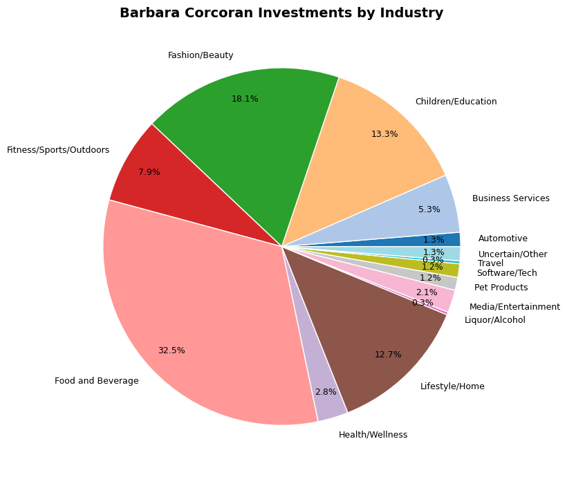

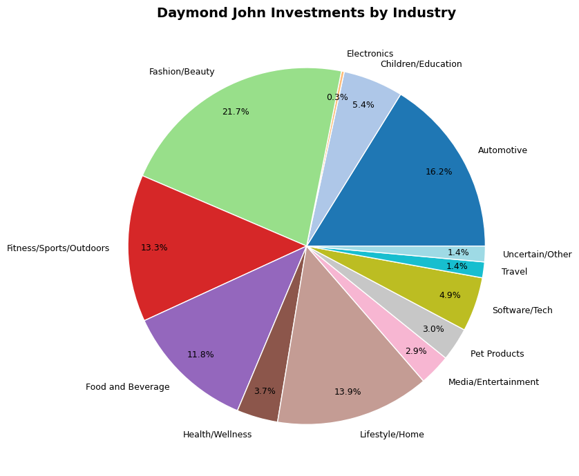

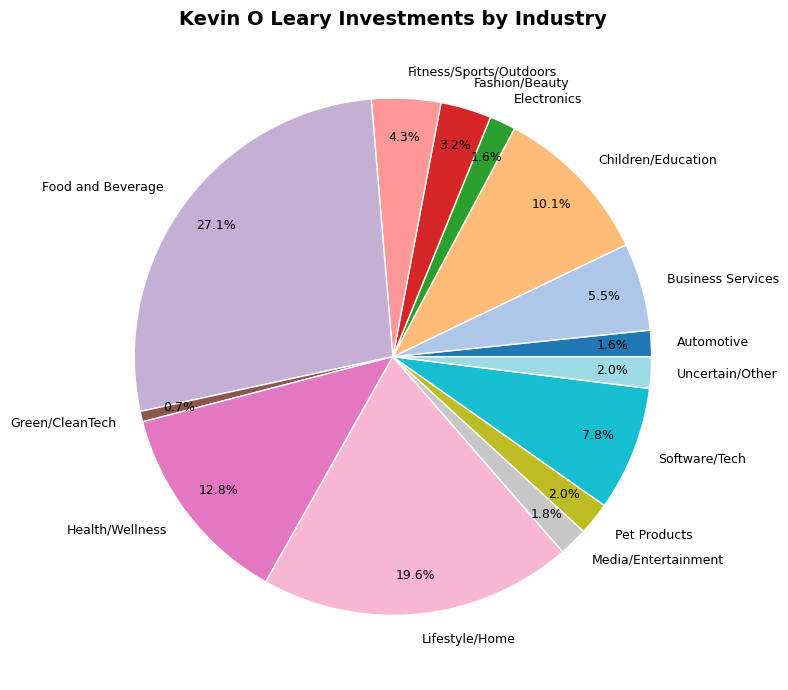

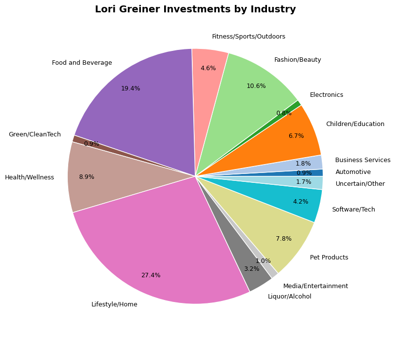

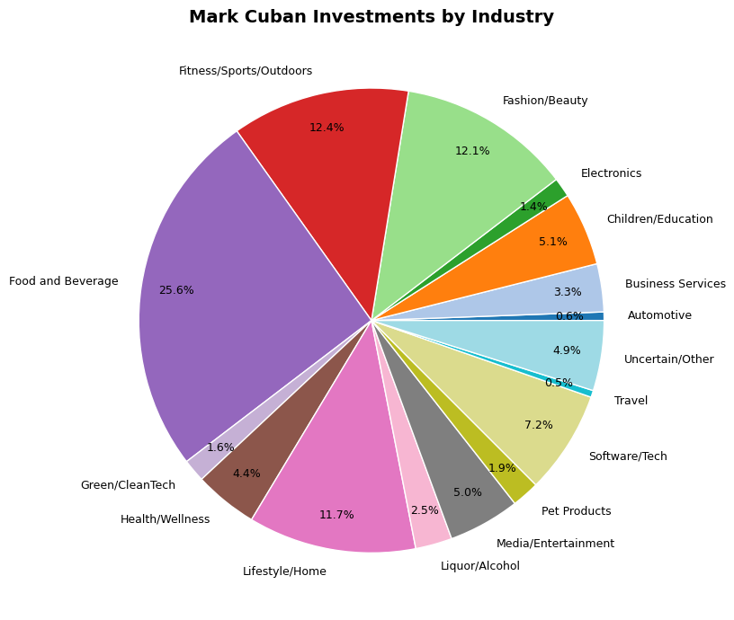

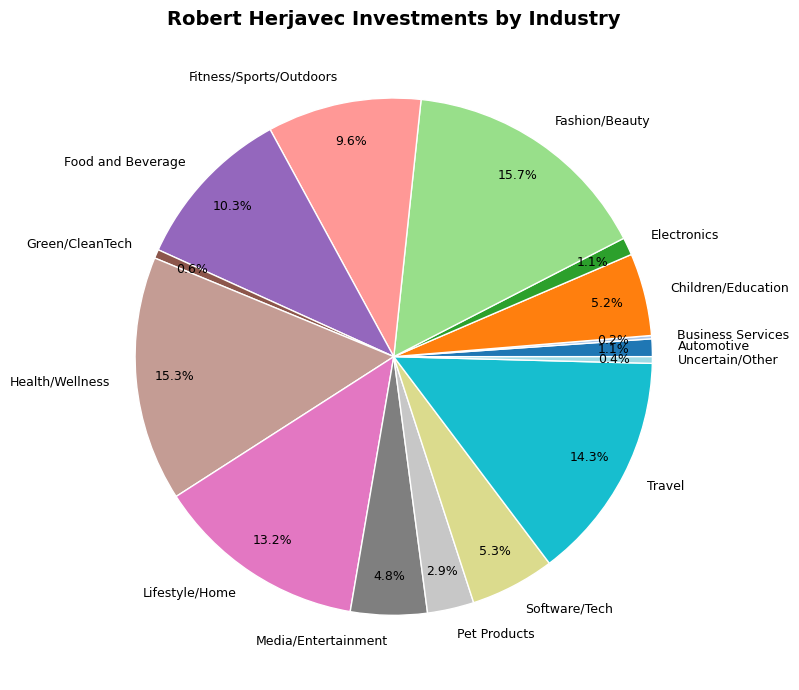

```python
total_nan_count = df.isna().sum().sum()
print("Total number of NaN values in the DataFrame:", total_nan_count)
```

```
Total number of NaN values in the DataFrame: 34467
```

```python
columns_to_drop = [
    'Season Start', 'Season End', 'Original Air Date', 'Pitch Number',
    'Company Website', 'Pitchers Average Age',
    'Total Deal Amount', 'Total Deal Equity', 'Deal Valuation',
    'Royalty Deal', 'Advisory Shares Equity', 'Loan', 'Deal Has Conditions', 'Barbara Corcoran Investment Equity',
    'Mark Cuban Investment Equity','Lori Greiner Investment Equity','Robert Herjavec Investment Equity','Daymond John Investment Equity',
    'Kevin O Leary Investment Equity',
    'Guest Investment Amount', 'Guest Investment Equity', 'Guest Name',
    'Guest Present', 'Got Deal', 'Number of Sharks in Deal', 'Investment Amount Per Shark',
    'Equity Per Shark', 'Episode Number', 'Season Number',  'Entrepreneur Names'
]

df = df.drop(columns=columns_to_drop)
print(df.columns)
```

We are dropping the above columns and the reasons are,

Season Start, Season End, Original Air Date: Temporal information irrelevant to prediction.

Pitch Number, Episode Number, Season Number: Episode-specific details not influencing investments.

Entrepreneur Names: Non-predictive and irrelevant to shark decisions.

Company Website: URL data not used for prediction unless analyzing content.

Pitchers Average Age: Potentially less impactful than other demographic or team features.

Total Deal Amount, Total Deal Equity, Deal Valuation: Outcome variables causing data leakage.

Got Deal: Target outcome for other predictions, not for individual shark investments.

Barbara Corcoran Investment Equity, Mark Cuban Investment Equity, etc.: Redundant for modeling investment amounts.

Guest Investment Amount, Guest Investment Equity, Guest Name, Guest Present: Guest-related columns not consistently informative.

Royalty Deal, Advisory Shares Equity, Loan, Deal Has Conditions: Deal structuring details not directly predictive.

Number of Sharks in Deal: Redundant if individual investments are included.

Investment Amount Per Shark, Equity Per Shark: Derived metrics not needed for prediction.

Selected column names

```
Index(['Startup Name', 'Industry', 'Business Description', 'Pitchers Gender',
       'Pitchers City', 'Pitchers State', 'Multiple Entrepreneurs',
       'US Viewership', 'Original Ask Amount', 'Original Offered Equity',
       'Valuation Requested', 'Barbara Corcoran Investment Amount',
       'Mark Cuban Investment Amount', 'Lori Greiner Investment Amount',
       'Robert Herjavec Investment Amount', 'Daymond John Investment Amount',
       'Kevin O Leary Investment Amount', 'Barbara Corcoran Present',
       'Mark Cuban Present', 'Lori Greiner Present', 'Robert Herjavec Present',
       'Daymond John Present', 'Kevin O Leary Present'],
      dtype='object')
```

```python
for col in df.columns:
    print(f"{col}: {df[col].iloc[0:6].values}")
```

Now we print some values for each of the selected columns

```
Startup Name: ['AvaTheElephant' "MrTod'sPieFactory" 'Wispots' 'CollegeFoxesPackingBoxes'
 'IonicEar' 'APerfectPear']
Industry: ['Health/Wellness' 'Food and Beverage' 'Business Services'
 'Lifestyle/Home' 'Software/Tech' 'Food and Beverage']
Business Description: ['Ava The Elephant - Baby and Child Care'
 "Mr. Tod's Pie Factory - Specialty Food" 'Wispots - Consumer Services'
 'College Foxes Packing Boxes - Consumer Services' 'Ionic Ear - Novelties'
 'A Perfect Pear - Specialty Food']
Pitchers Gender: ['Female' 'Male' 'Male' 'Male' 'Male' 'Female']
Pitchers City: ['Atlanta' 'Somerset' 'Cary' 'Tampa' 'St. Paul' 'Napa Valley']
Pitchers State: ['GA' 'NJ' 'NC' 'FL' 'MN' 'CA']
Multiple Entrepreneurs: [0. 0. 0. 0. 0. 0.]
US Viewership: [4.15 4.15 4.15 4.15 4.15 5.59]
Original Ask Amount: [  50000.  460000. 1200000.  250000. 1000000.  500000.]
Original Offered Equity: [15. 10. 10. 25. 15. 15.]
Valuation Requested: [  333333.  4600000. 12000000.  1000000.  6666667.  3333333.]
Barbara Corcoran Investment Amount: [ 50000. 230000.     nan     nan     nan     nan]
Mark Cuban Investment Amount: [nan nan nan nan nan nan]
Lori Greiner Investment Amount: [nan nan nan nan nan nan]
Robert Herjavec Investment Amount: [    nan     nan     nan     nan     nan 250000.]
Daymond John Investment Amount: [    nan 230000.     nan     nan     nan     nan]
Kevin O Leary Investment Amount: [    nan     nan     nan     nan     nan 250000.]
Barbara Corcoran Present: [1. 1. 1. 1. 1. 1.]
Mark Cuban Present: [0. 0. 0. 0. 0. 0.]
Lori Greiner Present: [0. 0. 0. 0. 0. 0.]
Robert Herjavec Present: [1. 1. 1. 1. 1. 1.]
Daymond John Present: [1. 1. 1. 1. 1. 1.]
Kevin O Leary Present: [1. 1. 1. 1. 1. 1.]
```

```python
df['Sharks Invested'] = df[['Barbara Corcoran Investment Amount',
                           'Mark Cuban Investment Amount',
                           'Lori Greiner Investment Amount',
                           'Robert Herjavec Investment Amount',
                           'Daymond John Investment Amount',
                           'Kevin O Leary Investment Amount']].notna().astype(int).values.tolist()
df['Sharks Investment Amounts'] = df[['Barbara Corcoran Investment Amount',
                                    'Mark Cuban Investment Amount',
                                    'Lori Greiner Investment Amount',
                                    'Robert Herjavec Investment Amount',
                                    'Daymond John Investment Amount',
                                    'Kevin O Leary Investment Amount']].values.tolist()
df['Sharks Investment Amounts'] = df['Sharks Investment Amounts'].apply(
    lambda x: [0 if pd.isna(val) else val for val in x]
)
columns_to_drop = [
    'Barbara Corcoran Investment Amount', 'Mark Cuban Investment Amount',
    'Lori Greiner Investment Amount', 'Robert Herjavec Investment Amount',
    'Daymond John Investment Amount', 'Kevin O Leary Investment Amount'
]
df = df.drop(columns=columns_to_drop)
```

In the above cell, we combine investment data for all sharks into two compact columns:

Sharks Invested: Binary indicators showing which sharks invested. Sharks Investment Amounts: The actual investment amounts (with 0 for no investment).

Simplifies the dataset by removing unnecessary individual columns.

Makes the data more suitable for machine learning models that can use these compact representations.

[output not shown]

```python
total_nan_count = df.isna().sum().sum()
print("Total number of NaN values in the DataFrame:", total_nan_count)
```

```
Total number of NaN values in the DataFrame: 4238
```

```python
nan_counts = df.isna().sum()
print("NaN counts per column:")
for col, count in nan_counts[nan_counts > 0].items():
    print(f"{col}: {count} NaN values")
```

```
NaN counts per column:
Pitchers Gender: 7 NaN values
Pitchers City: 834 NaN values
Pitchers State: 566 NaN values
Multiple Entrepreneurs: 427 NaN values
US Viewership: 4 NaN values
Original Ask Amount: 1 NaN values
Original Offered Equity: 1 NaN values
Valuation Requested: 1 NaN values
Barbara Corcoran Present: 423 NaN values
Mark Cuban Present: 373 NaN values
Lori Greiner Present: 373 NaN values
Robert Herjavec Present: 429 NaN values
Daymond John Present: 423 NaN values
Kevin O Leary Present: 376 NaN values
```

```python
df['Multiple Entrepreneurs'] = df['Multiple Entrepreneurs'].fillna(0)
df['US Viewership'] = df['US Viewership'].fillna(df['US Viewership'].median())
numeric_cols = ['Original Ask Amount', 'Original Offered Equity', 'Valuation Requested']
for col in numeric_cols:
    df[col] = df[col].fillna(df[col].median())
```

```python
present_columns = [col for col in df.columns if 'Present' in col]
for col in present_columns:
    df[col] = df[col].fillna(0)
```

```python
total_rows = len(df)
nan_counts = df.isna().sum()
print("NaN value analysis per column:")
for col, count in nan_counts[nan_counts > 0].items():
    percentage = (count / total_rows) * 100
    print(f"{col}: {count} NaN values out of {total_rows} total rows ({percentage:.1f}%)")
```

```python
df = df.drop(['Pitchers City', 'Pitchers State'], axis=1)
df['Pitchers Gender'] = df['Pitchers Gender'].fillna(0)
nan_counts = df.isna().sum()
print("NaN value analysis after changes:")
for col, count in nan_counts[nan_counts > 0].items():
    percentage = (count / total_rows) * 100
    if count > 0:
        print(f"{col}: {count} NaN values out of {total_rows} total rows ({percentage:.1f}%)")
```

[output not shown]

```python
for col in df.columns:
    print(f"{col}: {df[col].iloc[0:6].values}")
```

```
Startup Name: ['AvaTheElephant' "MrTod'sPieFactory" 'Wispots' 'CollegeFoxesPackingBoxes'
 'IonicEar' 'APerfectPear']
Industry: ['Health/Wellness' 'Food and Beverage' 'Business Services'
 'Lifestyle/Home' 'Software/Tech' 'Food and Beverage']
Business Description: ['Ava The Elephant - Baby and Child Care'
 "Mr. Tod's Pie Factory - Specialty Food" 'Wispots - Consumer Services'
 'College Foxes Packing Boxes - Consumer Services' 'Ionic Ear - Novelties'
 'A Perfect Pear - Specialty Food']
Pitchers Gender: ['Female' 'Male' 'Male' 'Male' 'Male' 'Female']
Multiple Entrepreneurs: [0. 0. 0. 0. 0. 0.]
US Viewership: [4.15 4.15 4.15 4.15 4.15 5.59]
Original Ask Amount: [  50000.  460000. 1200000.  250000. 1000000.  500000.]
Original Offered Equity: [15. 10. 10. 25. 15. 15.]
Valuation Requested: [  333333.  4600000. 12000000.  1000000.  6666667.  3333333.]
Barbara Corcoran Present: [1. 1. 1. 1. 1. 1.]
Mark Cuban Present: [0. 0. 0. 0. 0. 0.]
Lori Greiner Present: [0. 0. 0. 0. 0. 0.]
Robert Herjavec Present: [1. 1. 1. 1. 1. 1.]
Daymond John Present: [1. 1. 1. 1. 1. 1.]
Kevin O Leary Present: [1. 1. 1. 1. 1. 1.]
Sharks Invested: [list([1, 0, 0, 0, 0, 0]) list([1, 0, 0, 0, 1, 0])
 list([0, 0, 0, 0, 0, 0]) list([0, 0, 0, 0, 0, 0])
 list([0, 0, 0, 0, 0, 0]) list([0, 0, 0, 1, 0, 1])]
Sharks Investment Amounts: [list([50000.0, 0, 0, 0, 0, 0]) list([230000.0, 0, 0, 0, 230000.0, 0])
 list([0, 0, 0, 0, 0, 0]) list([0, 0, 0, 0, 0, 0])
 list([0, 0, 0, 0, 0, 0]) list([0, 0, 0, 250000.0, 0, 250000.0])]
```